# Downloading Map Features with OpenStreetMap in R

As a guide, use https://rspatialdata.github.io/osm.html

## Import of necessary libraries

The `osmdata` package in R can be used to download data from OpenStreetMap, similar to `osmnx` in Python. We will also use `sf` for handling spatial data, `ggplot2` for plotting, and `dplyr` for data manipulation.

## Using the osmdata R package to download a single OpenStreetmap feature

OpenStreetMap data can be accessed in R using the `osmdata` package. This package makes it easier to make Overpass API calls to download OSM data. We will download the outline of the hospital called “Klinikum Magdeburg” as an example.

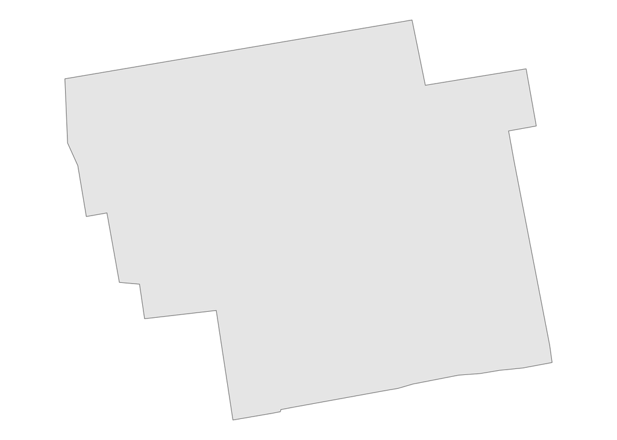

```r
# Geocode the hospital
hospital_query <- opq(bbox = 'Magdeburg, Germany') %>%
                  add_osm_feature(key = 'name', value = 'Klinikum Magdeburg') %>%
                  osmdata_sf()

# Extract the hospital data
hospital <- hospital_query$osm_polygons

# Plot the hospital
ggplot(data = hospital) +
  geom_sf() +
  theme_void()
```

Congratulations, you have downloaded and already visualized your first feature! If you still have some time to spare, you can continue on your own, for example, geocode a feature from your current place of living or home town, or continue with one of the following tasks.

## Coloring the feature differently

We can use the `ggplot2` library to color the features. Let’s color the hospital red.

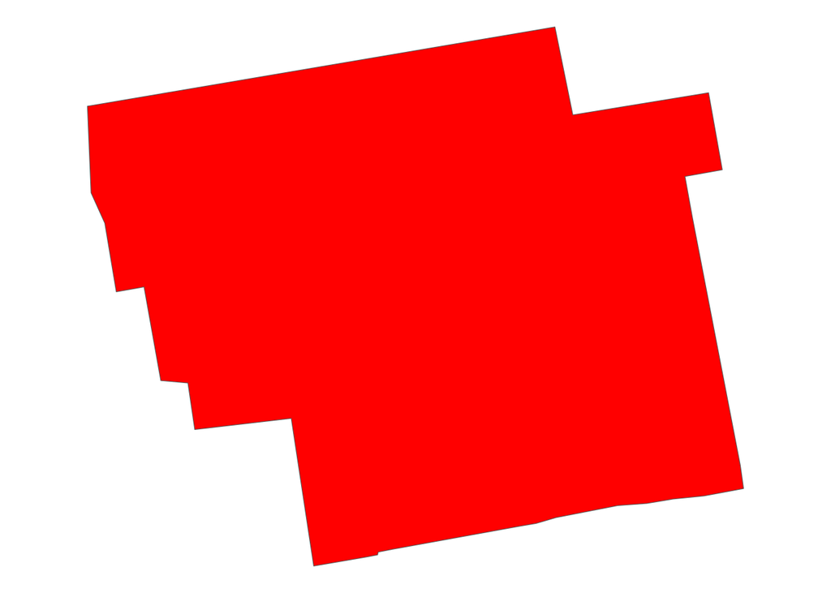

```r
ggplot(data = hospital) +
  geom_sf(fill="red") +
  theme_void()
```

## Display the hospital in the context of Magdeburg

We can use the `leaflet` library to add a little bit of interactivity.

```r
# Coordinates of Magdeburg
magdeburg_latitude <- 52.1205333
magdeburg_longitude <- 11.6276237

# Define a bounding box around Magdeburg
expanded_bbox <- c(magdeburg_longitude - 0.05, magdeburg_latitude - 0.05,
                   magdeburg_longitude + 0.05, magdeburg_latitude + 0.05)

# Geocode the hospital with the expanded bbox
hospital_query <- opq(bbox = expanded_bbox) %>%
                  add_osm_feature(key = 'name', value = 'Klinikum Magdeburg') %>%
                  osmdata_sf()
hospital <- hospital_query$osm_polygons

# Create a leaflet map
leaflet(data = hospital) %>%
  addTiles() %>%  # Add default OpenStreetMap map tiles
  addProviderTiles(providers$CartoDB.Positron) %>%
  addPolygons(data = hospital, color = "#ff7800", weight = 2, fillOpacity = 0.5, smoothFactor = 0.5) %>%
  setView(lng = magdeburg_longitude, lat = magdeburg_latitude, zoom = 12)
```

[interactive chart not shown]

## Extra credit

If you’ve reached this point, you’re likely already familiar with OpenStreetMap and the osmdata package or a fast learner. Here are some additional tasks:

1. Download and visualize all hospitals in Magdeburg.
2. Download Magdeburg’s street network and color it according to your preference.
3. Download Magdeburg’s rivers and color them blue.
4. Combine the city’s main boundary with all these features on a single map.